# 密度矩阵：从整体状态到局部描述

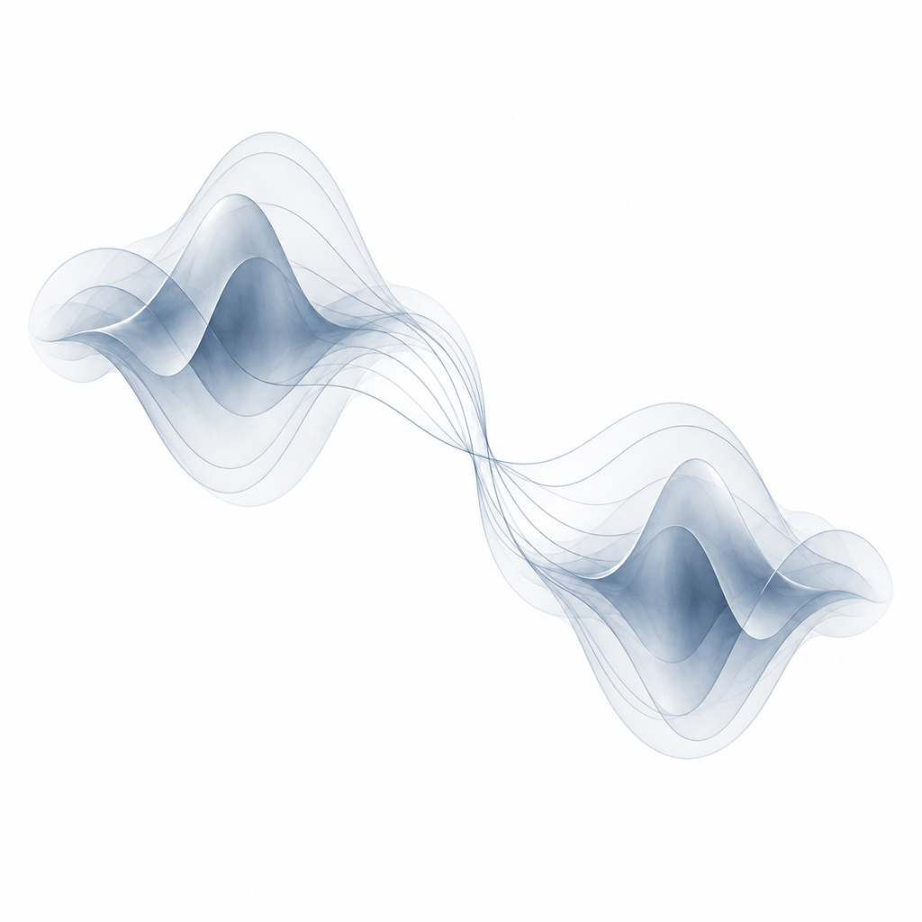

量子光学

第六讲

密度矩阵：从整体状态到局部描述

李梓民  
中南大学物理学院  
zimin.li@csu.edu.cn

zimin.li/quantum-optics/

# 会议日程

[figure not shown]

[interactive chart not shown]

# 本讲导读

1. 01

### 密度矩阵与相干性

   比较叠加态与随机混合，用密度矩阵统一计算测量概率。

   相位分散时，多轮平均的相干项可以减弱。
2. 02

### 偏迹与局部状态

   从联合概率求和，得到只描述Bob的约化密度矩阵。

   整体纯态可以给出混合的局部状态。
3. 03

### 纯态纠缠与局部熵

   比较一族联合纯态，用局部本征值计算熵。

   整体为纯态时，局部熵可以衡量双方纠缠。
4. 04

### 环境记录与退相干

   计算环境记录怎样改变系统的相干项。

   换测量基可以看出局部干涉的减弱。

# Bell态中，Bob自己的状态怎样写？

$$|\Phi^+\rangle_{AB}=\frac{|00\rangle+|11\rangle}{\sqrt2}$$

### 合并双方的记录

双方同测Z，只出现00、11，各占一半。

### 只保留Bob的记录

Bob的0、1结果各占一半。

### 思考

整体AB是一个纯态。只拿到Bob的量子比特，应当用什么描述它？

# 目录：密度矩阵与相干性

目录

CONTENTS

先比较两台单比特制备装置，找一个能统一描述纯态和随机混合的矩阵。

# 换成X测量，能区分两台装置吗？

$$|+\rangle=\frac{|0\rangle+|1\rangle}{\sqrt2}$$

### 装置A

每轮都制备$|+\rangle$。

### 装置B

每轮随机制备$|0\rangle$或$|1\rangle$，各占一半。

Z基为$\{|0\rangle,|1\rangle\}$；两台装置测Z都得到各半。

### 思考

X基为$\{|+\rangle,|-\rangle\}$，其中$|-\rangle=(|0\rangle-|1\rangle)/\sqrt2$。

两台装置测得正结果的概率分别是多少？

# 两台装置在X基给出不同概率

| 制备装置 | $P_Z(0)$ | $P_Z(1)$ | $P_X(+)$ | $P_X(-)$ |
| --- | --- | --- | --- | --- |
| A：每轮$\|+\rangle$ | $1/2$ | $1/2$ | 1 | 0 |
| B：随机$\|0\rangle,\|1\rangle$ | $1/2$ | $1/2$ | $1/2$ | $1/2$ |

装置B每个分支测X都给出各半；对两个分支加权后仍是各半。

一个方向的统计相同，还不足以说明两个状态相同。

要统一描述确定的纯态和随机混合，需要把制备概率也写进状态描述。

# 密度矩阵统一描述纯态和概率混合

### 每轮都是同一纯态

$$\rho=|\psi\rangle\langle\psi|$$

列向量与其共轭转置相乘。

### 按概率选择纯态

$$\rho=\sum_i p_i|\psi_i\rangle\langle\psi_i|$$

$p_i\ge0,\quad\sum_i p_i=1$。

例如$|0\rangle=(1,0)^T$，于是

$$|0\rangle\langle0|=\begin{pmatrix}1\\0\end{pmatrix}\begin{pmatrix}1&0\end{pmatrix}=\begin{pmatrix}1&0\\0&0\end{pmatrix}$$

当某一个分支的概率为1，混合的表达式就回到纯态。

# 相同的Z布居，不同的非对角元

### 装置A：$|+\rangle$

$$\rho_+=\frac12\begin{pmatrix}1&1\\1&1\end{pmatrix}$$

非对角元为$1/2$。

### 装置B：0、1各半混合

$$\rho_{\rm mix}=\frac12\begin{pmatrix}1&0\\0&1\end{pmatrix}=\frac I2$$

非对角元为0。

本页矩阵都用Z基表示；$I$是二维单位矩阵。

对角元给出Z结果概率；非对角元保留该基下的相干信息。

两矩阵对角元相同，换成X测量却能看出非对角元的差异。

# 密度矩阵直接给出测量结果的概率

若某个结果对应归一化态$|m\rangle$，各制备分支的概率相加：

$$P(m)=\sum_i p_i|\langle m|\psi_i\rangle|^2=\langle m|\rho|m\rangle$$

### 纯态$\rho_+=|+\rangle\langle+|$测X

$$P_X(+)=\langle+|\rho_+|+\rangle=1$$

### 0、1各半混合测X

$$P_X(+)=\langle+|\frac I2|+\rangle=\frac12$$

制备概率与各分支的Born概率相乘、相加，就得到密度矩阵的概率公式。

## 计算补充：两台装置的X概率

$$|+\rangle=\frac1{\sqrt2}\begin{pmatrix}1\\1\end{pmatrix}$$

$$\begin{aligned}\langle+|\rho_+|+\rangle&=\frac14(1,1)\begin{pmatrix}1&1\\1&1\end{pmatrix}\begin{pmatrix}1\\1\end{pmatrix}=1,\\\langle+|\rho_{\rm mix}|+\rangle&=\frac14(1,1)\begin{pmatrix}1&0\\0&1\end{pmatrix}\begin{pmatrix}1\\1\end{pmatrix}=\frac12.\end{aligned}$$

↑ 返回概率公式

# Z基没有非对角元，也可以是纯态

### 确定的纯态

$$\rho_0=|0\rangle\langle0|=\begin{pmatrix}1&0\\0&0\end{pmatrix}$$

Z测量必然得到0。

### 完全混合态

$$\rho_{\rm mix}=\begin{pmatrix}1/2&0\\0&1/2\end{pmatrix}$$

沿任意方向测量都各半。

判断纯态或混态，要看完整状态；某一基底中的非对角元只描述该基下的相干性。

# 相对相位保存在密度矩阵的非对角元中

$$|\psi_\phi\rangle=\frac{|0\rangle+e^{i\phi}|1\rangle}{\sqrt2}$$

$$\rho_\phi=\frac12\begin{pmatrix}1&e^{-i\phi}\\e^{i\phi}&1\end{pmatrix}$$

### 思考

每轮独立制备，$\phi$在$[0,2\pi)$均匀随机。

合并很多轮、又没有各轮的相位记录时，平均的非对角元会怎样？

$$\overline{e^{i\phi}}=0,\qquad\overline\rho=I/2$$

# 比较固定相位与随机相位的样本平均

相位分布

细灰：每轮相位因子  
粗蓝：这些箭头的平均

已抽取 **1** 轮制备相位

\(\bar c_N=\frac1N\sum_{j=1}^N e^{i\phi_j}\)

1.00 + 0.000 i

\(\bar\rho_N=\)

0.500.500.500.50

\(P_X(+)=\)**1.00**

理论系综平均：\(\overline\rho=|+\rangle\langle+|\)

固定相位：每轮箭头重合，平均箭头仍在单位圆上。

# 不同制备过程可以给出同一个平均态

随机相位输入为$|\psi_\phi\rangle=(|0\rangle+e^{i\phi}|1\rangle)/\sqrt2$。

### $\phi\in[0,2\pi)$均匀随机

$$\overline{e^{i\phi}}=0$$

$$\overline\rho=I/2$$

### 各半制备0、1

$$\rho=\frac12|0\rangle\langle0|+\frac12|1\rangle\langle1|$$

$$\rho=I/2$$

密度矩阵相同，针对该量子比特的所有测量概率就相同。

这里比较理论系综；有限抽样的平均相位通常不严格为零。

# 目录：偏迹与局部状态

目录

CONTENTS

已经能描述随机混合。现在从一个联合纯态，求Bob自己的密度矩阵。

# 乘积态中，Bob仍处于自己的纯态

$$|\Psi\rangle_{AB}=|+\rangle_A|0\rangle_B$$

### 整体密度算符

$$\rho_{AB}=|+\rangle_A\langle+|\otimes|0\rangle_B\langle0|$$

### 只观察Bob

$$\rho_B=|0\rangle_B\langle0|$$

Bob测Z必然得到0。

这个乘积态中，Bob处于$|0\rangle$；忽略Alice的记录不改变Bob的测量统计。

# 只保留Bob结果，就对Alice的结果求和

每轮制备$|\Phi^+\rangle=(|00\rangle+|11\rangle)/\sqrt2$，双方都测Z。

| Alice结果 | Bob为0 | Bob为1 |
| --- | --- | --- |
| 0 | $1/2$ | 0 |
| 1 | 0 | $1/2$ |

$$P_B(0)=P(0,0)+P(1,0)=\frac12$$

$$P_B(1)=P(0,1)+P(1,1)=\frac12$$

不按Alice的结果筛选数据，就把对应同一Bob结果的联合概率相加。

# 偏迹留下一个适用于Bob所有测量的矩阵

Bob测量的某个结果记为$|m\rangle_B$；Alice的正交基记为$|i\rangle_A$，$i=0,1$。

$$\begin{aligned}P_B(m)&=\sum_{i=0,1}\langle i,m|\rho_{AB}|i,m\rangle\\&=\langle m|\left[\sum_{i=0,1}{}_A\langle i|\rho_{AB}|i\rangle_A\right]|m\rangle.\end{aligned}$$

$$\rho_B=\operatorname{Tr}_A\rho_{AB}=\sum_{i=0,1}{}_A\langle i|\rho_{AB}|i\rangle_A$$

方括号内留下Bob的矩阵，称为约化密度矩阵。

对A取偏迹，求和的是A的自由度，留下的是B的状态。

# 对A求迹：A算成内积，B的算符留下

普通矩阵的迹是对角元之和。对A的正交基求和：

$$\operatorname{Tr}(|i\rangle\langle k|)=\sum_{a=0,1}\langle a|i\rangle\langle k|a\rangle=\langle k|i\rangle$$

$$\operatorname{Tr}_A\left(|i\rangle_A\langle k|\otimes M_B\right)=\langle k|i\rangle M_B$$

$M_B$是Bob的矩阵；A的指标相同，内积为1；不同则为0。

$$\operatorname{Tr}(|0\rangle\langle0|)=1$$

$$\operatorname{Tr}(I)=2$$

## 计算补充：核对乘积态的偏迹

$$\rho_{AB}=|+\rangle_A\langle+|\otimes|0\rangle_B\langle0|$$

$$\operatorname{Tr}_A\rho_{AB}=\underbrace{\operatorname{Tr}(|+\rangle\langle+|)}_{\langle+|+\rangle=1}|0\rangle_B\langle0|$$

Bob的状态保持为$|0\rangle\langle0|$，与原来的乘积态判断一致。

↑ 返回偏迹规则

# 哪一个交叉项会在偏迹后留下？

对Alice求偏迹，使用$\operatorname{Tr}_A(|i\rangle\langle k|\otimes M_B)=\langle k|i\rangle M_B$。

### 第一项

$$|00\rangle\langle11|$$

### 第二项

$$|00\rangle\langle01|$$

### 思考

分别写出A部分和B部分。哪一项为零？哪一项留下Bob的非对角算符？

# 偏迹保留A指标相同的项

拆开A、B对A算内积留下B算符

$$|00\rangle\langle11|$$

$$|0\rangle_A\langle1|\otimes|0\rangle_B\langle1|$$

$$\langle1|0\rangle=0$$

$$0$$

$$|00\rangle\langle01|$$

$$|0\rangle_A\langle0|\otimes|0\rangle_B\langle1|$$

$$\langle0|0\rangle=1$$

$$|0\rangle_B\langle1|$$

检查的是A的两个指标；B的非对角算符也可能留下。

# Bell纯态的Bob子系统是完全混合态

$$|\Phi^+\rangle_{AB}=\frac{|00\rangle+|11\rangle}{\sqrt2}$$

$$\begin{aligned}\rho_{AB}=\frac12\bigl(&|00\rangle\langle00|+|00\rangle\langle11|\\&+|11\rangle\langle00|+|11\rangle\langle11|\bigr).\end{aligned}$$

$$\operatorname{Tr}_A\rho_{AB}=\frac12|0\rangle\langle0|+\frac12|1\rangle\langle1|=\frac I2$$

两个交叉项因A指标不同而消失；两个对角项留下。

整体AB是纯态；Bob沿任意方向测量，两个结果都各占一半。

# Bob能区分Bell态与经典关联混态吗？

### Bell纯态

$$|\Phi^+\rangle=\frac{|00\rangle+|11\rangle}{\sqrt2}$$

### 经典关联混态

$$\rho_{AB}^{\rm cl}=\frac12|00\rangle\langle00|+\frac12|11\rangle\langle11|$$

### 思考

对经典关联混态求偏迹。Bob只测自己的粒子，能区分这两个整体态吗？

$$\operatorname{Tr}_A\rho_{AB}^{\rm cl}=I/2$$

两者给出相同的Bob状态，所以Bob的任何局域测量都无法区分它们。

# 合并双方的X结果，可以区分这两个整体态

### Bell纯态

$$|\Phi^+\rangle=\frac{|++\rangle+|--\rangle}{\sqrt2}$$

| Alice结果 | Bob结果 | 概率 |
| --- | --- | --- |
| $+$ | $+$ | $1/2$ |
| $+$ | $-$ | 0 |
| $-$ | $+$ | 0 |
| $-$ | $-$ | $1/2$ |

### 经典关联混态

各半选择$|00\rangle$或$|11\rangle$。  
分支内独立：$1/2\times1/2=1/4$。

| Alice结果 | Bob结果 | 概率 |
| --- | --- | --- |
| $+$ | $+$ | $1/4$ |
| $+$ | $-$ | $1/4$ |
| $-$ | $+$ | $1/4$ |
| $-$ | $-$ | $1/4$ |

Bell态中，同一轮两人同正或同负；Bob单独的正、负结果仍各半。

# 第一课时：从整体态算出局部统计

| 具体任务 | 得到的描述 |
| --- | --- |
| 把制备概率计入状态 | $\rho=\sum_i p_i\|\psi_i\rangle\langle\psi_i\|$ |
| 只观察Bob | $\rho_B=\operatorname{Tr}_A\rho_{AB}$ |
| Bell态中的Bob | $\rho_B=I/2$ |

Bell态有纠缠，经典关联混态无纠缠；Bob的局部状态却同为$I/2$。

仅凭局部混合程度无法判断纠缠。下一课时限定整体为纯态，再比较。

# 目录：纯态纠缠与局部熵

目录

CONTENTS

整体已知是纯态时，局部状态的混合程度怎样随纠缠改变？

# 改变联合纯态的权重，比较Bob的局部状态

$$|\psi_p\rangle=\sqrt p\,|00\rangle+\sqrt{1-p}\,|11\rangle,\qquad0\le p\le1$$

$$\rho_B=p|0\rangle\langle0|+(1-p)|1\rangle\langle1|$$

### 思考

当$p$从$1/2$增加到1，整体和Bob分别接近哪个态？纠缠会怎样变化？

# 权重取零或一时为乘积态，等权时为Bell态

### $p=0$

$$|\psi_0\rangle=|11\rangle$$

$$\rho_B=|1\rangle\langle1|$$

Bob为纯态。

### $p=1/2$

$$|\psi_{1/2}\rangle=|\Phi^+\rangle$$

$$\rho_B=I/2$$

Bob完全混合。

### $p=1$

$$|\psi_1\rangle=|00\rangle$$

$$\rho_B=|0\rangle\langle0|$$

Bob为纯态。

当$p$从$1/2$增加到1时，整体接近$|00\rangle$，Bob接近$|0\rangle$。

用一个数比较中间状态，需要先选定描述状态不确定性的方法。

# 同一个纯态，测量结果的熵可以不同

Shannon熵描述一组结果概率$\{q_k\}$的不确定性：

$$H=-\sum_kq_k\log_2q_k,\qquad 0\log_2 0=0$$

固定输入态$|+\rangle=(|0\rangle+|1\rangle)/\sqrt2$，只改变测量基：

| 测量基 | 两个结果的概率 | 结果熵 |
| --- | --- | --- |
| Z | $(1/2,1/2)$ | $1\ \mathrm{bit}$ |
| X | $(1,0)$ | $0$ |

测量结果熵随测量基改变，输入的纯态并未改变。

# 状态熵采用密度矩阵的本征值

在一组归一化、正交的本征态中，$\rho|v_k\rangle=\lambda_k|v_k\rangle$。

$$P(v_k)=\langle v_k|\rho|v_k\rangle=\lambda_k$$

同一个状态换基表示，本征值不变。用它们定义von Neumann熵：

$$S(\rho)=-\sum_k\lambda_k\log_2\lambda_k$$

对数底为2，单位为bit；约定$0\log_2 0=0$。

本征值给出本征基中的概率，也使状态熵不依赖任意选定的测量方向。

# 纯态熵为零，完全混合态熵为1 bit

### 纯态$\rho_+=|+\rangle\langle+|$

$$\rho_+|+\rangle=|+\rangle$$

$$\rho_+|-\rangle=0$$

本征值为1、0。

$$S(\rho_+)=0$$

### 完全混合态$I/2$

$$\frac I2|0\rangle=\frac12|0\rangle$$

$$\frac I2|1\rangle=\frac12|1\rangle$$

本征值为$1/2,1/2$。

$$S(I/2)=1\ \mathrm{bit}$$

# 本征值各半时，Bob的局部熵最大

仍考察$|\psi_p\rangle=\sqrt p\,|00\rangle+\sqrt{1-p}\,|11\rangle$。

两侧偏迹均得$\rho_A=\rho_B=\mathrm{diag}(p,1-p)$：对角矩阵作用于0、1基矢，分别乘上$p,1-p$。

$$S(\rho_B)=-p\log_2p-(1-p)\log_2(1-p)$$

$S(\rho_B)\ (\mathrm{bit})$

| $p$ | 整体纯态 | 局部熵 |
| --- | --- | --- |
| 0 | $\|11\rangle$ | 0 |
| $1/2$ | $\|\Phi^+\rangle$ | 1 bit |
| 1 | $\|00\rangle$ | 0 |

# 整体为纯态时，局部熵可以量化纠缠

对处于联合纯态的A、B，两个约化态的熵满足：

$$S(\rho_A)=S(\rho_B)$$

这个共同值称为A与B的纠缠熵；为零对应乘积纯态。

### Bell纯态

$$|\Phi^+\rangle=\frac{|00\rangle+|11\rangle}{\sqrt2}$$

Bob的$\rho_B=I/2$，熵为1 bit；AB最大纠缠。

### 经典关联混态

$$\rho_{AB}^{\rm cl}=\frac12|00\rangle\langle00|+\frac12|11\rangle\langle11|$$

Bob也有1 bit局部熵，AB是乘积态的概率混合。

把局部熵称为纠缠熵，需要整体为纯态这一条件。

# 目录：环境记录与退相干

目录

CONTENTS

把Alice换成环境：环境留下不同记录后，系统自己的测量概率会怎样？

# 环境为系统的两个分量留下不同记录

系统初态为$|+\rangle_S$，环境初态为归一化的$|E_{\rm in}\rangle$。

输出记录态$|E_0\rangle,|E_1\rangle$都归一化，彼此未必正交。

### 系统处于0

$$|0\rangle|E_{\rm in}\rangle\longrightarrow|0\rangle|E_0\rangle$$

### 系统处于1

$$|1\rangle|E_{\rm in}\rangle\longrightarrow|1\rangle|E_1\rangle$$

对叠加输入使用同一个线性演化，得到联合态：

$$|\Psi\rangle_{SE}=\frac{|0\rangle|E_0\rangle+|1\rangle|E_1\rangle}{\sqrt2}$$

这里保持系统的0、1布居，研究环境记录怎样影响局部相干性。

# 哪一种环境记录更能保留系统相干性？

$$|\Psi\rangle_{SE}=\frac{|0\rangle|E_0\rangle+|1\rangle|E_1\rangle}{\sqrt2}$$

### 记录相同

$$|E_0\rangle=|E_1\rangle$$

### 记录完全可区分

$$\langle E_1|E_0\rangle=0$$

### 思考

第一种联合态可以怎样因式分解？第二种记录对系统的0、1分量留下了什么信息？

# 环境记录相同时，联合态仍是乘积态

$$|\Psi\rangle_{SE}=\frac{|0\rangle|E_0\rangle+|1\rangle|E_1\rangle}{\sqrt2}$$

### 两种记录相同

$$|\Psi\rangle_{SE}=|+\rangle_S|E_0\rangle$$

环境状态与系统的0、1分量无关。

### 两种记录正交

$$\langle E_1|E_0\rangle=0$$

正交记录分别对应系统的0、1，联合态与Bell态有相同的纠缠结构。

要预测只观察系统S的结果，接下来对环境求偏迹。

# 对环境求偏迹，交叉项留下记录态内积

把联合态$|\Psi\rangle_{SE}=\frac{|0\rangle|E_0\rangle+|1\rangle|E_1\rangle}{\sqrt2}$写成外积。交叉项包含$|E_0\rangle\langle E_1|$。

在环境的正交完备基$\{|n\rangle_E\}$中求迹：

$$\operatorname{Tr}_E(|E_0\rangle\langle E_1|)=\sum_n\langle n|E_0\rangle\langle E_1|n\rangle=\langle E_1|E_0\rangle$$

$$\rho_S=\frac12\begin{pmatrix}1&\langle E_1|E_0\rangle\\\langle E_0|E_1\rangle&1\end{pmatrix}$$

记录态的归一化保留对角元，两个记录态的内积决定交叉项。

# 环境记录的重叠决定系统非对角元

$$\gamma=\langle E_1|E_0\rangle,\qquad\rho_S=\frac12\begin{pmatrix}1&\gamma\\\gamma^*&1\end{pmatrix}$$

| 环境记录 | 重叠幅度 | 系统相干性 |
| --- | --- | --- |
| 相同 | $\gamma=1$ | 保留原来的$\|+\rangle$ |
| 部分可区分 | $0<\|\gamma\|<1$ | 相干项幅度减小 |
| 正交、完全可区分 | $\gamma=0$ | 变为$I/2$ |

环境可以区分两个系统分量时，系统自身的相干性会减弱。

这一过程称为退相干；环境不需要被观察者实际读取。

# 要观察相干项减小，应当测Z还是测X？

固定系统初态$|+\rangle_S$。取实数$0\le\gamma\le1$，环境态为

$$|E_0\rangle=|0\rangle_E,\quad |E_1\rangle=\gamma|0\rangle_E+\sqrt{1-\gamma^2}|1\rangle_E$$

$$\rho_S=\frac12\begin{pmatrix}1&\gamma\\\gamma&1\end{pmatrix}$$

### 思考

让$\gamma$从1减到0。Z基与X基中，哪组概率会改变？

用$P(m)=\langle m|\rho_S|m\rangle$检查你的判断。

# X测量能看出相干项减弱，Z布居保持各半

$$\rho_S=\frac12\begin{pmatrix}1&\gamma\\\gamma&1\end{pmatrix},\quad 0\le\gamma\le1$$

### Z基

$$P_Z(0)=P_Z(1)=\frac12$$

由两个对角元直接读出。

### X基：$|+\rangle=(|0\rangle+|1\rangle)/\sqrt2$

$$P_X(+)=\langle+|\rho_S|+\rangle=\frac{1+\gamma}{2}$$

$$P_X(-)=\frac{1-\gamma}{2}$$

| $\gamma$ | $P_X(+)$ | $P_X(-)$ | $P_Z(0)$ |
| --- | --- | --- | --- |
| 1 | 1 | 0 | $1/2$ |
| 0 | $1/2$ | $1/2$ | $1/2$ |

只测Z会错过这里的相干变化；换到X基，两个结果从确定变成各半。

## 计算补充：复相位怎样进入测量概率

$$\rho_S=\frac12\begin{pmatrix}1&\gamma\\\gamma^*&1\end{pmatrix}$$

$$P_X(+)=\frac{1+\operatorname{Re}\gamma}{2}$$

测量态取$|+_\theta\rangle=(|0\rangle+e^{i\theta}|1\rangle)/\sqrt2$，则

$$P(+_\theta)=\frac{1+\operatorname{Re}(\gamma e^{i\theta})}{2}$$

改变$\theta$可以读取不同相位的相干信息；相干幅度由$|\gamma|$决定。

↑ 返回实重叠模型

# 改变环境重叠，同时比较两组测量概率

记录态重叠 \(\gamma\) 1.00

环境记录态的实系数示意

蓝：\(|E_0\rangle\) 棕：\(|E_1\rangle\)

两条箭头重合：环境记录相同。

系统的约化密度矩阵

\(\rho_S=\)

0.500.500.500.50

非对角元：\(\gamma/2=\)**0.50**

Z 基测量

\(P_Z(0)\)

0.50

\(P_Z(1)\)

0.50

X 基测量

\(P_X(+)\)

**1.00**

\(P_X(-)\)

**0.00**

记录完全相同：相干项为 0.5，X 测量必然得到正结果。

# 整体保持纯态，系统局部仍可变成混态

### 整体S与E

$$|+\rangle_S|E_{\rm in}\rangle\longrightarrow|\Psi\rangle_{SE}$$

$$|\Psi\rangle_{SE}=\frac{|0\rangle|E_0\rangle+|1\rangle|E_1\rangle}{\sqrt2}$$

初态和末态各由一个态矢量描述，整体保持纯态。

### 只观察系统S

$$\rho_S=\operatorname{Tr}_E|\Psi\rangle\langle\Psi|$$

环境记录正交时，$\rho_S=I/2$。

环境记录可区分时，系统与环境产生纠缠；偏迹给出只测系统的统计。

对比Bell态$|\Phi^+\rangle=(|00\rangle+|11\rangle)/\sqrt2$：对Alice求偏迹，Bob也得到$I/2$。

# 从制备到局部测量，四个问题已经连起来

$$|\Phi^+\rangle_{AB}=\frac{|00\rangle+|11\rangle}{\sqrt2}$$

$$|\Psi\rangle_{SE}=\frac{|0\rangle|E_0\rangle+|1\rangle|E_1\rangle}{\sqrt2}$$

| 问题 | 本讲得到的计算方法 |
| --- | --- |
| 纯态与随机混合怎样统一描述？ | $\rho=\sum_i p_i\|\psi_i\rangle\langle\psi_i\|$ |
| 只观察Bob，怎样算状态？ | $\rho_B=\operatorname{Tr}_A\rho_{AB}$ |
| 联合纯态的纠缠怎样比较？ | $S(\rho_B)=-\sum_k\lambda_k\log_2\lambda_k$ |
| 环境怎样影响局部干涉？ | $\rho_{01}=\langle E_1\|E_0\rangle/2$ |

Bell态整体是纯态，Bob的约化态却是$I/2$；局部测量由这个矩阵预测。

# 课堂自查：偏迹与测量概率

### 思考

1. 对A取偏迹，$|00\rangle\langle01|$会留下什么？解释检查了谁的指标。

2. 系统的局部态用Z基$|0\rangle,|1\rangle$表示：

$$\rho_S=\frac12\begin{pmatrix}1&0.6\\0.6&1\end{pmatrix}$$

X正结果态为$|+\rangle=(|0\rangle+|1\rangle)/\sqrt2$。求X正结果和Z的0结果概率。

1. A的内积为$\langle0|0\rangle=1$，留下$|0\rangle_B\langle1|$。

2. $P_X(+)=(1+0.6)/2=0.8$；$P_Z(0)=0.5$。

# 一键三连

[figure not shown]